# Penguins

Mia Fitzgerald

4/21/2026

### Loading Three Worksheets

```r
penguins_t_xl <- read_excel("penguins.xlsx", sheet = "Torgersen Island", na = "NA")
penguins_b_xl <- read_excel("penguins.xlsx", sheet = "Biscoe Island", na = "NA")
penguins_d_xl <- read_excel("penguins.xlsx", sheet = "Dream Island", na = "NA")
```

I am using the read_excel function to import three specific sheets—Torgersen, Biscoe, and Dream Island—from a single Excel workbook. By setting na = “NA”, I ensure that any text entries labeled “NA” are converted into true missing values so they don’t interfere with my future calculations. Finally, I am assigning each sheet to its own unique tibble so I can store and organize the data within my R environment. [^1]

### Stacking the Three Worksheets

```r
combined_penguins <- bind_rows(penguins_b_xl, penguins_d_xl, penguins_t_xl)
```

I am using the bind_rows() function to stack the three individual island tibbles—Biscoe, Dream, and Torgersen—into a single master dataset. [^2]

### Bill Depth Versus Bill Length by Island

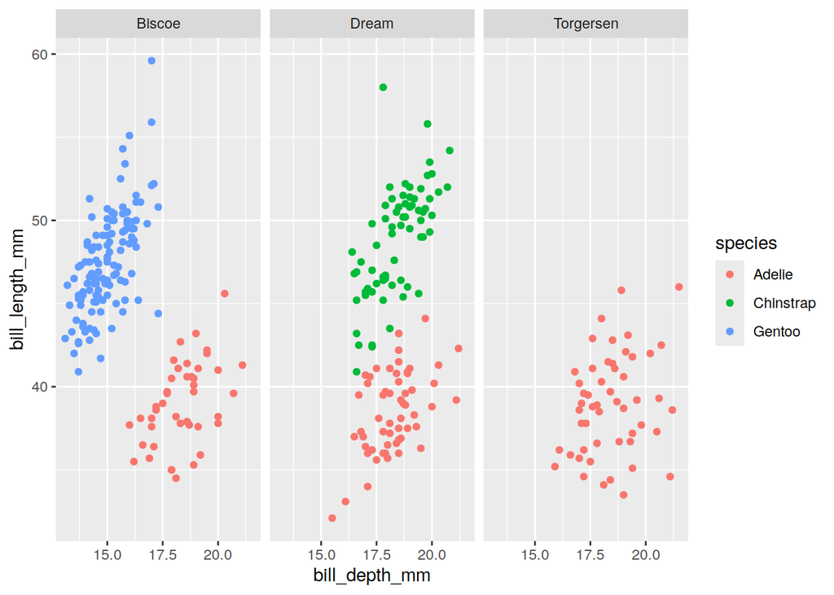

```r
combined_penguins %>%
  ggplot(aes(x = bill_depth_mm, y = bill_length_mm, color = species)) +
  geom_point() +
  facet_wrap(~island)
```

I am creating a scatter plot to visualize the relationship between penguin bill depth and bill length across the three islands. By using aes(color = species), I am assigning a unique color to each species so I can easily distinguish between them on the plot. [^3]

### Average Body Masses for the Different Penguin Species

```r
combined_penguins %>%
  select(species, body_mass_g) %>%
  group_by(species) %>%
  summarize(avg_body_mass = mean(body_mass_g, na.rm = TRUE)) %>%
  kable()
```

| species | avg_body_mass |
| --- | --- |
| Adelie | 3700.662 |
| Chinstrap | 3733.088 |
| Gentoo | 5076.016 |

I first select only the species and body mass columns, then group the data by species to calculate the average body mass while ignoring any missing values. Finally, I use the kable() function to convert the resulting data into a professional-looking table suitable for a report or document. [^4]

### Started a New, Temporary DuckDB Database

```r
con <- DBI::dbConnect(duckdb::duckdb())
```

In this line, I am establishing a connection to a new, temporary DuckDB database that lives entirely in my computer’s RAM. [^5]

### Tibble to the Database

```r
dbWriteTable(con, "combined_penguins", combined_penguins)
```

I am taking the combined_penguins tibble from my R environment and writing it into the DuckDB database as a table. [^6]

### dbplyr Connection to Penguins DB table

```r
combined_penguins_db <- tbl(con, "combined_penguins")
combined_penguins_db %>%
  collect()
```

```
## # A tibble: 344 × 8
##    species island bill_length_mm bill_depth_mm flipper_length_mm body_mass_g
##    <chr>   <chr>           <dbl>         <dbl>             <dbl>       <dbl>
##  1 Adelie  Biscoe           37.8          18.3               174        3400
##  2 Adelie  Biscoe           37.7          18.7               180        3600
##  3 Adelie  Biscoe           35.9          19.2               189        3800
##  4 Adelie  Biscoe           38.2          18.1               185        3950
##  5 Adelie  Biscoe           38.8          17.2               180        3800
##  6 Adelie  Biscoe           35.3          18.9               187        3800
##  7 Adelie  Biscoe           40.6          18.6               183        3550
##  8 Adelie  Biscoe           40.5          17.9               187        3200
##  9 Adelie  Biscoe           37.9          18.6               172        3150
## 10 Adelie  Biscoe           40.5          18.9               180        3950
## # ℹ 334 more rows
## # ℹ 2 more variables: sex <chr>, year <dbl>
```

I am creating a dbplyr reference that points R to the specific table inside my database. In the second line, I use collect() to force R to actually download that data from the database and bring it into my local environment as a usable table. [^7]

### SQL Query of Using the DB to Calculate the Average Body Masses for the Different Penguin Species

```r
combined_penguins_db %>%
  select(species, body_mass_g) %>%
  group_by(species) %>%
  summarize(avg_body_mass = mean(body_mass_g, na.rm = TRUE)) %>%
  show_query()
```

```
## <SQL>
## SELECT species, AVG(body_mass_g) AS avg_body_mass
## FROM (
##   SELECT species, body_mass_g
##   FROM combined_penguins
## ) q01
## GROUP BY species
```

I am using dbplyr to perform a calculation entirely within the database. I first select the species and body mass columns, group them by species, and calculate the average mass. Finally, by using show_query(), I am asking R to display the underlying SQL code it generated to talk to the database instead of showing the actual data results. [^8]

[^1]: Question 1 complete
[^2]: Question 2 complete
[^3]: Question 3 complete
[^4]: Question 4 complete
[^5]: Question 5 complete
[^6]: Question 6 complete
[^7]: Question 7 complete
[^8]: Question 8 complete